# Solutions for Activity 10: Confounding variables

Notes and in-class exercises

## Exercise 1: Review

```r
# Load useful packages and data
library(readr)
library(ggplot2)
library(dplyr)
peaks <- read_csv("https://mac-stat.github.io/data/high_peaks.csv") %>%
    mutate(ascent = ascent / 1000)

# Check it out
head(peaks)
```

```
# A tibble: 6 × 7
  peak           elevation difficulty ascent length  time rating
  <chr>              <dbl>      <dbl>  <dbl>  <dbl> <dbl> <chr>
1 Mt. Marcy           5344          5   3.17   14.8  10   moderate
2 Algonquin Peak      5114          5   2.94    9.6   9   moderate
3 Mt. Haystack        4960          7   3.57   17.8  12   difficult
4 Mt. Skylight        4926          7   4.26   17.9  15   difficult
5 Whiteface Mtn.      4867          4   2.54   10.4   8.5 easy
6 Dix Mtn.            4857          5   2.8    13.2  10   moderate
```

```r
peaks_model <- lm(time ~ length + ascent + rating, data = peaks)
coef(summary(peaks_model))
```

```
                 Estimate Std. Error   t value     Pr(>|t|)
(Intercept)     6.5106514 1.62983740  3.994663 2.627176e-04
length          0.4590819 0.08158314  5.627166 1.465288e-06
ascent          0.1874830 0.34215350  0.547950 5.866973e-01
ratingeasy     -3.1685224 0.86219113 -3.674965 6.827232e-04
ratingmoderate -2.4767827 0.61058560 -4.056405 2.177589e-04
```

- `length` coefficient:
  - Among hikes with the same vertical ascent and challenge rating, each additional mile of the hike is associated with a 0.46 hour increase in completion time on average.
  - Holding vertical ascent and challenge rating constant (fixed), each additional mile of the hike is associated with a 0.46 hour increase in completion time on average.
- `ratingeasy` coefficient:
  - Among hikes with the same length and vertical ascent, the average completion time of easy hikes is 3.2 hours less than that of difficult hikes (reference category).
  - Holding constant hike length and vertical ascent, the average completion time of easy hikes is 3.2 hours less than that of difficult hikes.

## Exercise 2: Confounders

```r
# Import data
cps <- read_csv("https://mac-stat.github.io/data/cps_2018.csv") %>%
    filter(age >= 18, age <= 34) %>%
    filter(wage < 250000)
# Check it out
head(cps)
```

```
# A tibble: 6 × 8
   wage   age education marital industry   health    hours education_level
  <dbl> <dbl>     <dbl> <chr>   <chr>      <chr>     <dbl> <chr>
1 75000    33        16 single  management fair         40 bachelors
2 33000    19        16 single  management very_good    40 bachelors
3 43000    33        16 married management good         40 bachelors
4 50000    32        12 single  management excellent    40 HS
5 14400    28        12 single  service    excellent    40 HS
6 33000    31        16 married management very_good    45 bachelors
```

age, education, job industry, …

## Exercise 3: Controlling for confounders

1. create 2 separate groups that are as similar as possible with respect to these variables. give the groups different remedies.
2. we’d have to get 2 groups that are similar with respect to age, and assign 1 group to get married and 1 group to be single. that would be weird (and unethical).

## Exercise 4: Age

```r
# Construct the model
wage_model_2 <- lm(wage ~ marital + age, cps)
coef(summary(wage_model_2))
```

```
                Estimate Std. Error   t value     Pr(>|t|)
(Intercept)   -19595.948  3691.6998 -5.308110 1.184066e-07
maritalsingle  -7500.146  1191.8526 -6.292847 3.545964e-10
age             2213.869   120.7701 18.331265 2.035782e-71
```

1. .

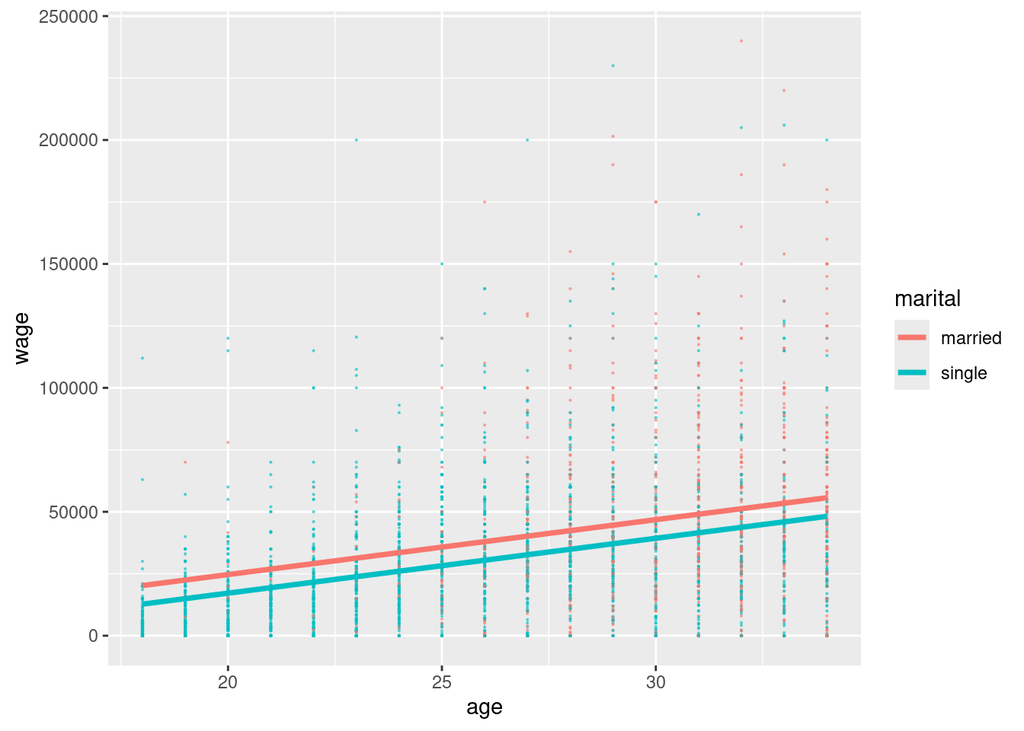

```r
cps %>%
ggplot(aes(y = wage, x = age, color = marital)) +
    geom_point(size = 0.1, alpha = 0.5) +
    geom_line(aes(y = wage_model_2$fitted.values), size = 1.25)
```

2. -$7500
3. - When controlling for (“holding constant”) age, single workers make $7500 less than married workers on average.
   - Among workers of the same age, single workers make $7500 less than married workers on average.

## Exercise 5: More confounders

```r
wage_model_3 <- lm(wage ~ marital + age + education, cps)
coef(summary(wage_model_3))
```

```
                Estimate Std. Error    t value     Pr(>|t|)
(Intercept)   -64898.607  4099.8737 -15.829416 2.254709e-54
maritalsingle  -6478.094  1119.9345  -5.784351 7.988760e-09
age             1676.796   116.3086  14.416777 1.102113e-45
education       4285.259   207.2158  20.680173 3.209448e-89
```

1. 2 planes: There are 2 quantitative predictors which form the dimensions of the plane. The marital status categorical predictor creates 2 planes.
2. The `maritalsingle` coefficient is of main interest:
   - Among workers of the same age and years of education, single workers earn $6478 less than married workers.
3. - `age` coefficient: Among workers of the same marital status and years of education, each additional year of age is associated with a $1677 increase in salary on average.
   - `education` coefficient: Among workers of the same marital status and age, each additional year of education is associated with a $4285 increase in salary on average.

## Exercise 6: Even more

```r
wage_model_4 <- lm(wage ~ marital + age + education + industry, cps)
coef(summary(wage_model_4))
```

```
                                  Estimate Std. Error    t value     Pr(>|t|)
(Intercept)                     -52498.857  7143.8481 -7.3488206 2.533275e-13
maritalsingle                    -5892.842  1105.6898 -5.3295615 1.053631e-07
age                               1493.360   116.1673 12.8552586 6.651441e-37
education                         3911.117   243.0192 16.0938565 4.500408e-56
industryconstruction              5659.082  6218.5649  0.9100302 3.628760e-01
industryinstallation_production   1865.650  6109.2613  0.3053806 7.600964e-01
industrymanagement                1476.884  6031.2901  0.2448704 8.065727e-01
industryservice                  -7930.403  5945.6509 -1.3338158 1.823603e-01
industrytransportation           -1084.176  6197.2462 -0.1749448 8.611342e-01
```

1. Among workers of the same job industry, education, and age, single workers make $5893 less than a married worker on average.
2. highest = construction (because it has the highest positive coefficient), lowest = service (because it has the most negative coefficient)

## Exercise 7: Biggest model yet

```r
wage_model_5 <- lm(wage ~ marital + age + education + industry + hours + health, cps)
coef(summary(wage_model_5))
```

```
                                   Estimate Std. Error     t value     Pr(>|t|)
(Intercept)                     -64886.5747 6914.18198 -9.38456275 1.171028e-20
maritalsingle                    -4992.7685 1061.84882 -4.70195794 2.687274e-06
age                               1061.1410  115.83503  9.16079518 9.031462e-20
education                         3443.7625  236.12723 14.58435151 1.128646e-46
industryconstruction              5381.3857 5959.05620  0.90306007 3.665630e-01
industryinstallation_production   2951.0372 5854.23981  0.50408547 6.142365e-01
industrymanagement                5107.6364 5782.95334  0.88322283 3.771832e-01
industryservice                  -3074.5127 5705.56537 -0.53886207 5.900201e-01
industrytransportation            -207.3439 5940.02074 -0.03490626 9.721567e-01
hours                              732.1340   43.72488 16.74410733 2.340115e-60
healthfair                       -7407.7981 2901.71339 -2.55290483 1.072955e-02
healthgood                       -2470.8096 1259.44276 -1.96182766 4.987035e-02
healthpoor                       -9086.9110 7657.43781 -1.18667774 2.354441e-01
healthvery_good                    292.5278 1020.89213  0.28654136 7.744823e-01
```

## Exercise 8: Reflection

1. These confounders explained away more and more of the wage gap between single and married workers.
2. Answers will vary. A potential factor that we haven’t considered is a worker’s role within a given industry.

## Exercise 9: A new (extreme) example

| clarity | description |
| --- | --- |
| IF | flawless (no internal imperfections) |
| VVS1 | very very slightly imperfect |
| VVS2 | ” ” |
| VS1 | very slightly imperfect |
| VS2 | ” ” |
| SI1 | slightly imperfect |
| SI2 | ” ” |
| I1 | imperfect |

```r
diamond_model_1 <- lm(price ~ clarity, data = diamonds)

# Get a model summary
coef(summary(diamond_model_1))
```

```
               Estimate Std. Error    t value     Pr(>|t|)
(Intercept)  3677.41676   25.88161 142.086092 0.000000e+00
clarity.L   -1723.35264   98.72036 -17.456913 4.696367e-68
clarity.Q    -428.36467   96.70081  -4.429794 9.450847e-06
clarity.C     647.87442   83.30820   7.776838 7.567234e-15
clarity^4    -123.13052   66.72533  -1.845334 6.499443e-02
clarity^5     804.80570   54.62487  14.733320 4.907171e-49
clarity^6    -273.65013   47.67881  -5.739449 9.549240e-09
clarity^7      81.18721   42.01910   1.932150 5.334619e-02
```

1. highest = SI2, lowest = VVS1
2. will vary.

## Exercise 10: Size

```r
diamond_model_2 <- lm(price ~ clarity + carat, data = diamonds)

# Get a model summary
coef(summary(diamond_model_2))
```

```
               Estimate Std. Error      t value      Pr(>|t|)
(Intercept) -2977.26896   13.11110 -227.0799509  0.000000e+00
clarity.L    4216.77507   33.65424  125.2969766  0.000000e+00
clarity.Q   -1931.40632   31.87080  -60.6011296  0.000000e+00
clarity.C    1005.84704   27.39341   36.7185805 1.486332e-291
clarity^4    -480.17830   21.94294  -21.8830399 1.089041e-105
clarity^5     283.94435   17.97527   15.7963882  4.403172e-56
clarity^6      12.66308   15.68062    0.8075624  4.193461e-01
clarity^7     198.04828   13.81518   14.3355543  1.597902e-46
carat        8440.05729   12.65126  667.1315412  0.000000e+00
```

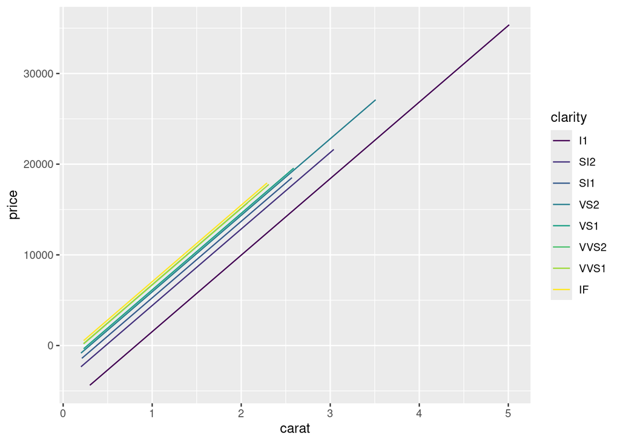

```r
# Plot the model
diamonds %>%
    ggplot(aes(y = price, x = carat, color = clarity)) +
    geom_line(aes(y = diamond_model_2$fitted.values))
```

highest = IF, lowest = I1 (reference category)

This is what we would have expected!